# Lab 6.2 - Directory of visualizations (II): Visualizing relationships, trends and uncertainty

# 2 Visualizing trends

When making scatter plots or time series, we are often more interested in the overarching trend of the data than in the specific detail of where each individual data point lies. By drawing the trend on top of or instead of the actual data points, usually in the form of a straight or curved line, we can create a visualization that helps the reader immediately see key features of the data.

Smoothing lines and fitter regression lines are the usual way to go. Note that the concept of *trend* is not restricted to time series analysis. The simplest way to display a trend is by fitting a linear profile to our data, either by `smoothing` or `regression`. The first can be understood as a kind of moving average calculated over the data while the second implies adjusting some sort of regression model (lm, glm or gam, mainly). Regardless of the approach, we use `geom_smooth` to do the trick. Let`s recover our first plot showing fire counts over the years and add a trend line over it:

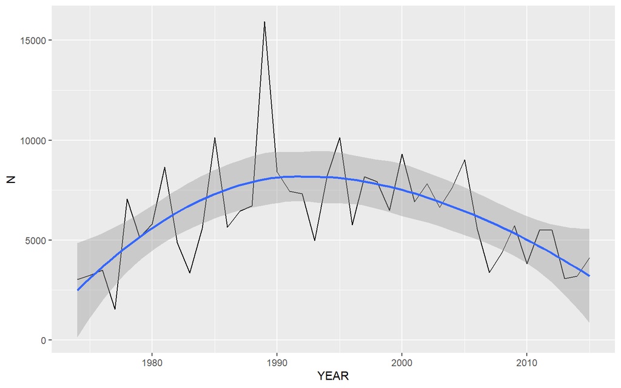

```r
fires %>%
    filter(YEAR > 1900) %>%
    group_by(YEAR) %>%
    summarize(N = n()) %>%
    ggplot(aes(x = YEAR, y = N)) + geom_line() + geom_smooth()
```

By default, `geom_smooth` fits a LOESS spline line that helps interpreting the evolution. We can change the `method` to `lm` (linear regression) or `gam` (Generalized Additive Models) to reproduce the fitting outcome of any of those modeling approaches:

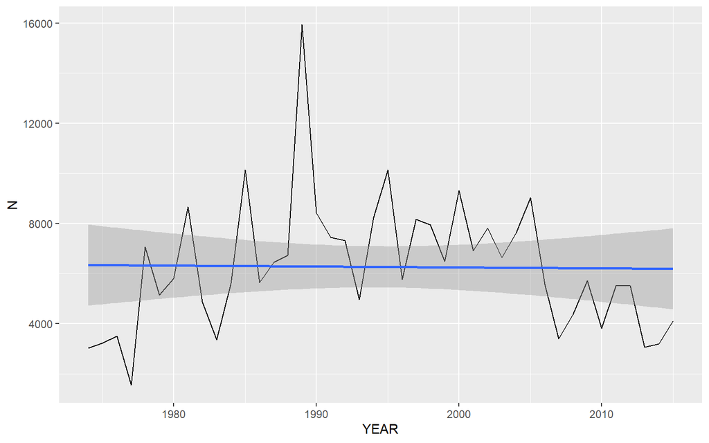

```r
fires %>%
    filter(YEAR > 1900) %>%
    group_by(YEAR) %>%
    summarize(N = n()) %>%
    ggplot(aes(x = YEAR, y = N)) + geom_line() + geom_smooth(method = "lm")
```

Of course, smoothing is not restritec to time series of data, and a relationship linear profile can be fitted to any bivariate combination of data.

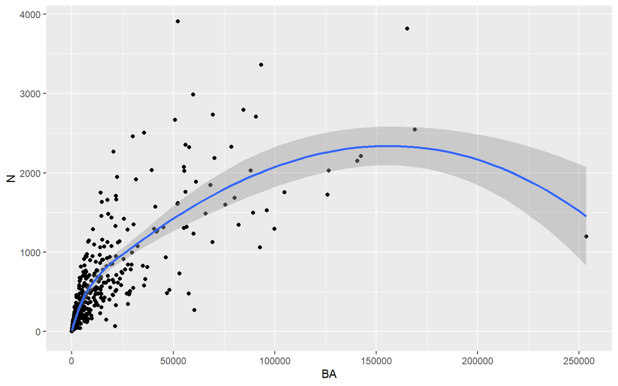

```r
fires %>%
    group_by(YEAR, MONTH) %>%
    summarise(BA = sum(BAREA), N = n()) %>%
    ggplot(aes(x = BA, y = N)) + geom_point() + geom_smooth()
```

To dig in into the potential differences in the relationships by categories, we can map a class into color and `geom_smooth` will automatically fit a profile for each category:

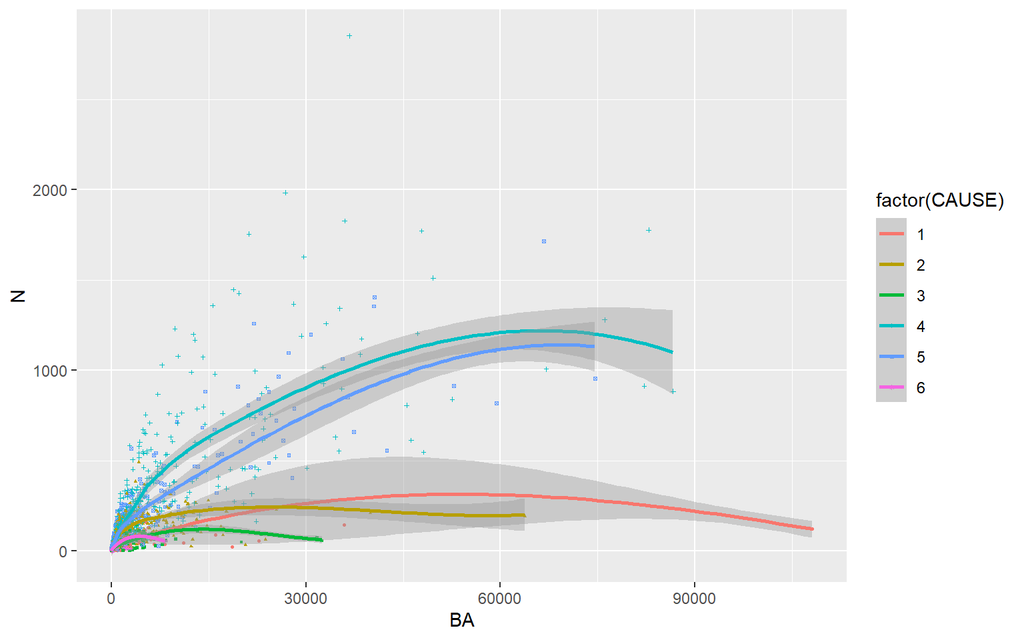

```r
fires %>%
    group_by(YEAR, MONTH, CAUSE) %>%
    summarise(BA = sum(BAREA), N = n()) %>%
    ggplot() + geom_point(aes(x = BA, y = N, color = factor(CAUSE), shape = factor(CAUSE)),
    size = 0.5) + geom_smooth(aes(x = BA, y = N, color = factor(CAUSE)))
```

# 3 Visualizing uncertainty

One of the most challenging aspects of data visualization is the visualization of uncertainty. When we see a data point drawn in a specific location, we tend to interpret it as a precise representation of the true data value. It is difficult to conceive that a data point could actually lie somewhere it hasn’t been drawn. Yet this scenario is ubiquitous in data visualization. Nearly every data set we work with has some uncertainty, and whether and how we choose to represent this uncertainty can make a major difference in how accurately our audience perceives the meaning of the data.

The most common approach to indicate uncertainty are error bars. The basic idea is to complement any kind of central measure (mean, median…) with an indicator of dispersion (sd, IQR…). To do so, we represent the central measure with a bar or point and add the error bars by adding and substracting the dispersion measure. Reporting uncertainty is key to properly understand data. Compare what happens when we just plot the mean:

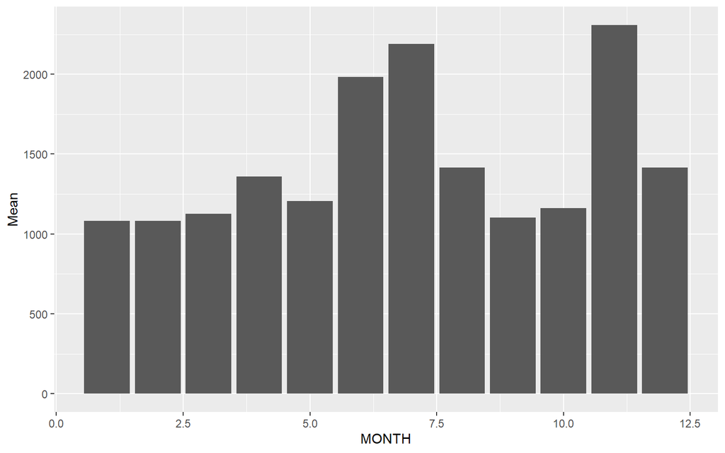

```r
fires %>%
    filter(BAREA > 500) %>%
    group_by(MONTH) %>%
    summarise(Mean = mean(BAREA), SD = sd(BAREA)) %>%
    ggplot(aes(x = MONTH, y = Mean)) + geom_col()
```

And the result when we account for uncertainty:

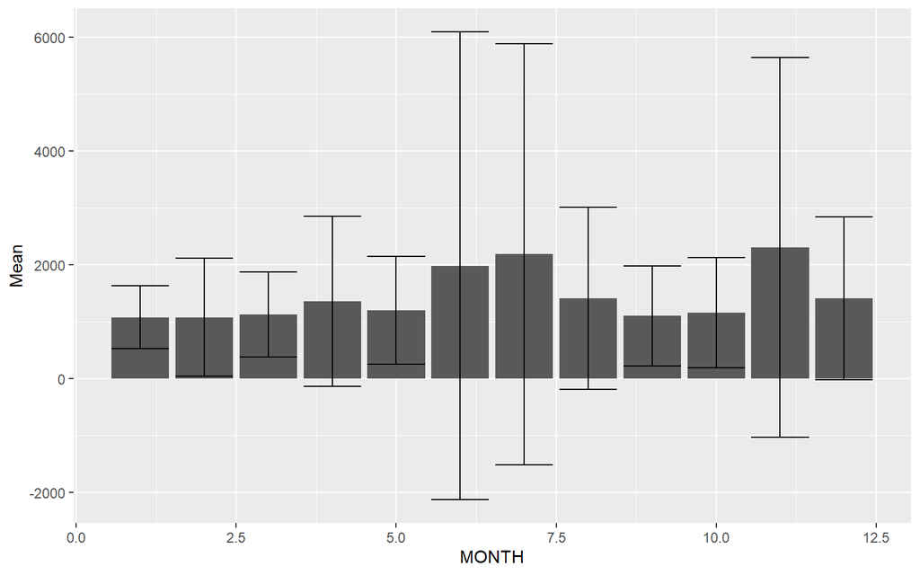

```r
fires %>%
    filter(BAREA > 500) %>%
    group_by(MONTH) %>%
    summarise(Mean = mean(BAREA), SD = sd(BAREA)) %>%
    ggplot(aes(x = MONTH, y = Mean)) + geom_col() + geom_errorbar(aes(ymin = Mean -
    SD, ymax = Mean + SD))
```

The same can be done using dot plots:

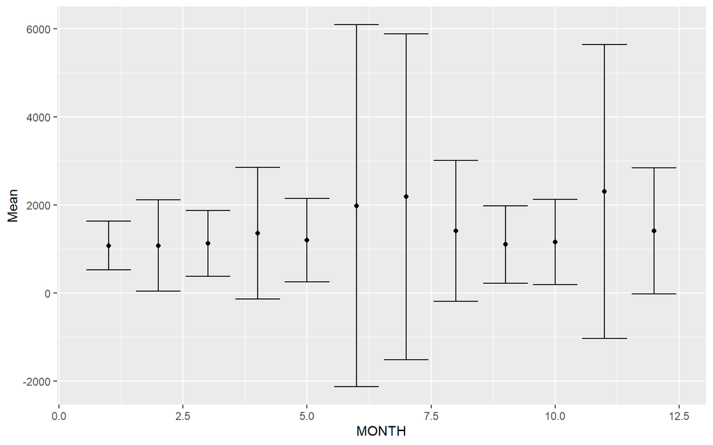

```r
fires %>%
    filter(BAREA > 500) %>%
    group_by(MONTH) %>%
    summarise(Mean = mean(BAREA), SD = sd(BAREA)) %>%
    ggplot(aes(x = MONTH, y = Mean)) + geom_point() + geom_errorbar(aes(ymin = Mean -
    SD, ymax = Mean + SD))
```

Or even color:

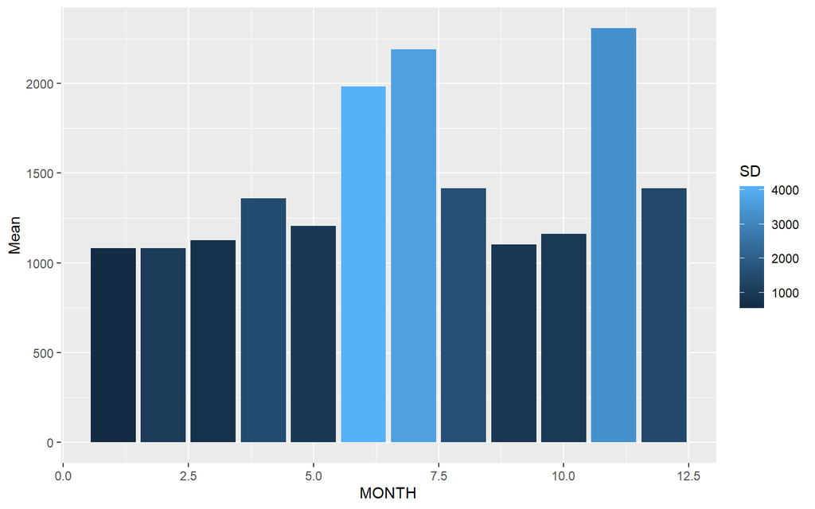

```r
fires %>%
    filter(BAREA > 500) %>%
    group_by(MONTH) %>%
    summarise(Mean = mean(BAREA), SD = sd(BAREA)) %>%
    ggplot(aes(x = MONTH, y = Mean, fill = SD)) + geom_col()
```

**EXERCISE 2**

Represent the relationship between tree height and diameter using the `trees` dataset. Explore potential differences among provinces or the most representative species.